# Experiment 3: More Airline Data

Asynchronous Lecture

2023-09-11

This experiment (conceptually) continues our class work on flight data.

We will continue to refer to (https://r4ds.hadley.nz/data-transform).

**However, we will expand and update our data set by going to a root source — the Bureau of Transportation.

(https://www.transtats.bts.gov/DL_SelectFields.aspx?gnoyr_VQ=FIM&QO_fu146_anzr=Nv4%20Pn44vr45) This data set allows access to information on domestic flights and domestic carriers, with monthly summary data.

# Packages

```r
library(nycflights13)
library(tidyverse)
library(here)
library(janitor)
```

# Got data from online source.

## Loading the BOT data

We take advantage of the ‘here’ package to get the path to the file that we stored, We also may note that inside the zip file is a .csv file. We will read the .csv file.

```r
thisfile = here("data_raw", "DL_SelectFields.zip")

df2022 = read_csv(thisfile) %>% clean_names()
```

## Subsetting to data of interest

Let’s focus on flights from LaGuardia (airport “LGA”) and eliminate cargo flights by requiring at least 1 passenger.

Call the resultant data frame ‘df9’.

```r
df9 = df2022 |>
  filter(passengers > 0, origin == "LGA")
```

# Exploring the BOT 2022 data

## Subsetting to data of interest

Let’s try to visualize a monthly count of flights using a bar chart.

First, a not quite right visualization.

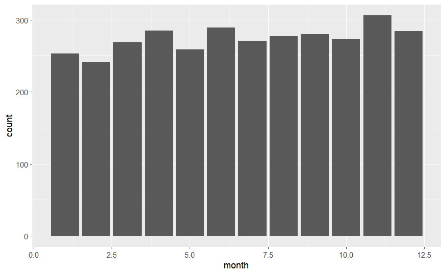

```r
df9 |> ggplot(aes(month)) + geom_bar()
```

By default, ‘geom_bar’ is counting the number of rows, where we have asked it to visualize the count by ‘month’.

** Take a look at the data set and discover why counting rows is not going to give us a count of flights. **

The visualization we want is:

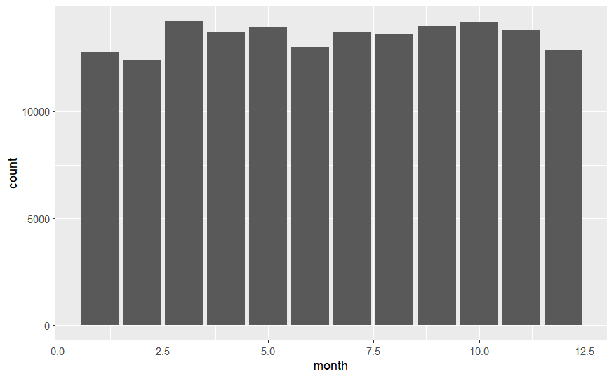

```r
df9 |> ggplot(aes(month)) + geom_bar(aes(weight = departures_performed))
```

Make some observations about this plot.

### A new visualization

Can you make a box plot where the bar height is based on the number of passengers riding each month?

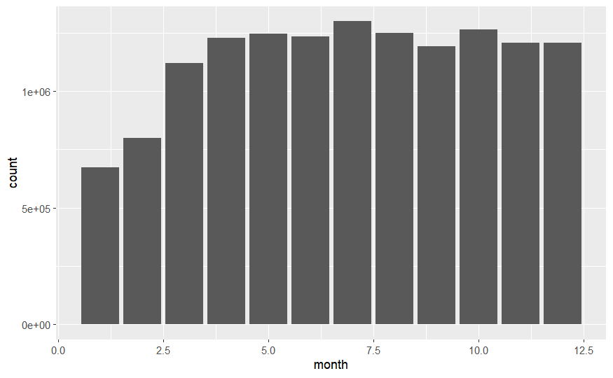

```r
df9 |> ggplot(aes(month)) + geom_bar(aes(weight = passengers))
```

Observation: * Low passenger numbers in early 2022 likely due to COVID-19.

### Just because you can

Here is pretty, but not so useful plot.

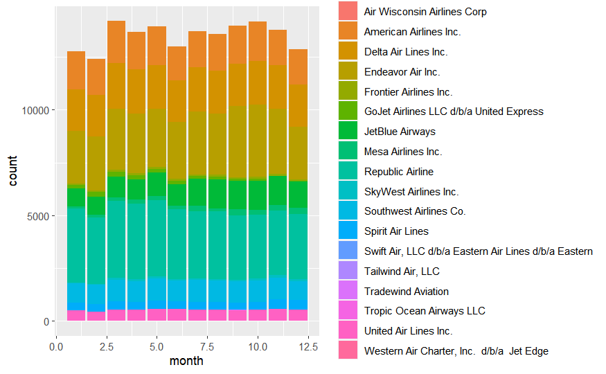

```r
df9 |>
  ggplot(aes(month, fill = carrier_name)) + geom_bar(aes(weight = departures_performed))
```

## Arrivals and departures from LGA

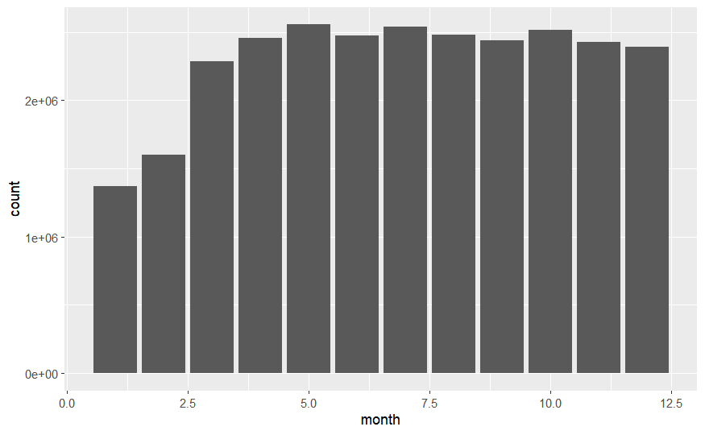

```r
df10 = df2022 |> filter(passengers > 0, origin == "LGA" | dest == "LGA")

df10 |> ggplot(aes(month)) + geom_bar(aes(weight = passengers))
```

```r
df11 = df10 |>
  select(month, passengers, seats, carrier_name, dest, origin)
```

```r
df12 = df10 |> select(1:5, month, contains("id"))
```

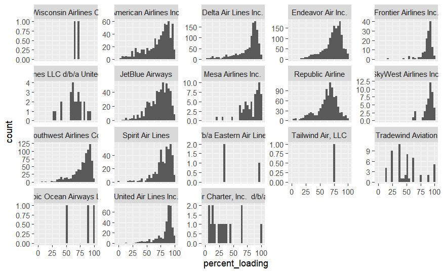

```r
df13 = df11 |> mutate(percent_loading = passengers / seats * 100)

df13 |>
  ggplot(aes(percent_loading)) +
  geom_histogram() + facet_wrap(~carrier_name, scales = "free_y")
```